# Cross-validation of regression models: mixed model examples (edited v2)

John Fox and Georges Monette

2023-10-15

The following artificial data set exemplifies striking aspects of cross-validation with hierarchical models. Model comparisons using cluster-based versus individual-based cross-validation may not agree on a best model. Furthermore, commonly-used measures of fit, such as least-squares, do not necessarily become smaller as models becomes larger.

Varying the parameters of the model, particularly the between-subject variance relative to the within-subject variance, can also reveal strong differences in the behaviour of different algorithms used to fit mixed models. These issues are not pursued in any depth in this vignette.

This example exhibits both phenomena described above. Consider a researcher studying the improvement in a skill, yodelling for example, among students enrolled in a four-year yodelling program. The plan is to measure each student’s skill level at the beginning of the program and every year thereafter until the end of the program, resulting in five annual measurements for each student.

The researcher, with more expertise in yodelling than modelling, decides to model the response $Y$, yodelling skill, against age, $X$, reasoning that students get older during their stay in the program, and age can serve as a proxy for elapsed time. The researcher knows that a mixed model should be used to account for clustering due to the expected similarity of measurements taken from each student.

The figures below show the pattern of responses expected from a representative subset of individuals.

The between-student effect of age is zero but the within-student effect is 1. Due to the large variation in ages between students, a least-squares model fitting age as a predictor would produce an estimated slope that is close to zero, since the estimated slope is heavily weighted toward the between-student effect. Consider a mixed model using the same fixed-effects model with the addition of a random intercept.

In the example below, the model applies little shrinkage, allowing a large variability in the heights of fitted lines, which approach closely the observed values for each student. Consequently, the model’s fit is similar to that of a fixed-effects model with an effect of age together with a categorical predictor for individual students. Thus, the model fits individual observations well, resulting in a favourable assessment using individual-based cross-validation. In contrast, the very large variability in the BLUPs results in large residuals for cluster-based cross-validation, producing an unfavourable assessment compared with the smaller model using only a random intercept.

By comparison, if the mixed model had applied considerable shrinkage, neither the between-cluster nor the between-individual cross-validations would have shown much improvement over the random-intercept only model. In our experience, the degree of shrinkage does not vary smoothly as parameters are changed but tends to be “all or nothing.” Its behaviour is affected considerably by the choice of the algorithm used to fit the model.

Finally, a model that also includes a compositional variable consisting of the mean age of each student, results in the random intercept BLUPs representing variation in the students’ fitted lines measured at the mean age of each student. Thus, with this example, both the cluster-based and the individual-based fits are relatively good.

To serve as a comparison, we also include cross-validation using the model known to have generated the data, namely a model with a between-subject age effect equal to zero by modelling the response $Y$ with a fixed effects model using an age centered within each student, i.e. the age at assessment less the mean age of each student’s assessments, plus a random term for each student.

A closely related question is that of non-convergence of mixed-model algorithms. Adjusting the parameters generating this data can be used to create examples illustrating problems of non-convergence with hierarchical models. Fitted models with relatively small between-cluster variance, even those using simple random intercept models, are prone to non-convergence due to the nature of optimizing algorithms used in `lme` and `lmer`.

In some contexts, non-convergence, can be viewed as a diagnostic of a poor model. However, with a simple random intercept model where it may indicate a small between-cluster variance, non-convergence is an annoyance because it would be statistically correct to report that the data are consistent with a zero between-cluster population variance, i.e. that observed between-cluster variance in the data can be explained by the between-individual variability within clusters. This leads to valid statistical inferences. Although the calculation of accurate p-values for hypotheses concerning random effects may be complicated by the fact that the estimated variance is at the boundary of the parameter space, the estimated variance-covariance matrix of fixed-effect parameters will generally be non-singular and may be used for valid Wald tests of linear hypotheses of fixed-effect parameters.

Using cross-validation based on fitting random subsets compounds the problem since subsets for which there is non-convergence cause the cross-validation to fail unless non-converging subsets are omitted, which may bias results since non-convergence is likely to be related to the estimated between-cluster variances.

Varying the parameter for between-cluster variance (`SDre` in the code below), will generate data sets with varying propensities to produce non-convergence. These data sets can be used to explore the consequences of non-convergence and to compare the performance of different optimizers.

At present, the results below are based on a data set that does not produce non-convergence and are limited to comparisons obtained by varying two factors:

- Four models: random intercept only, adding x as a predictor, adding the group means of x (xm) as a predictor, and a fourth model with a random intercept and x centered within each student.
- Cross-validation resampling individual cases or resampling clusters.

Since the independence of clusters may be a reasonable assumption, as is the the independence of individual observations from the same cluster *conditional* on clusters, each form of resampling addresses the suitability of models to answer different questions. Results based on individual resampling generalize to new samples from the same clusters. Resampling clusters generalizes to new samples of clusters and cases.

We start by generating and plotting the data.

```r
# Generate data set

# Parameters:
set.seed(9693)
Nb <- 100    # number of groups
Nw <- 5      # number of individuals within groups
Bb <- 0      # between-group regression coefficient on group mean
SDre <- 2.0  # between-group SD of random level relative to group mean of x
SDwithin <- 0.5  # within group SD
Bw <- 1     # within group effect of x
Ay <- 10    # intercept for response
Ax <- 20    # starting level of x
Nx <- Nw*10 # number of distinct x values

Data <- data.frame(
  group = factor(rep(1:Nb, each=Nw)),
  x = Ax + rep(1:Nx, length.out = Nw*Nb)
) |>
  within(
    {
      xm  <- ave(x, group, FUN = mean) # within-group mean
      y <- Ay +
        Bb * xm +                  # contextual effect
        Bw * (x - xm) +            # within-group effect
        rnorm(Nb, sd=SDre)[group] +  # random level by group
        rnorm(Nb*Nw, sd=SDwithin)    # random error within groups
    }
  )
```

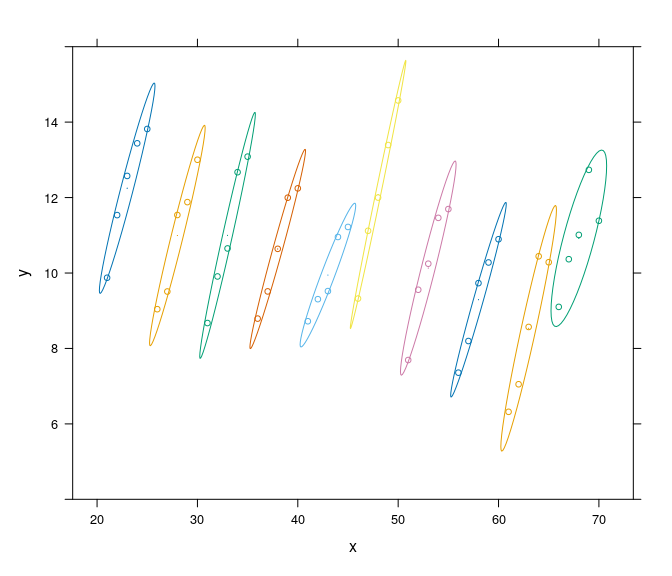

Hierarchical data set, showing first 10 of 100 clusters.

```r
plot <- xyplot(y ~ x, data=Data[1:Nx, ], group=group,
               ylim=c(4, 16),
               par.settings=list(superpose.symbol=list(pch=1, cex=0.7))) +
    layer(panel.ellipse(..., center.cex=0))
plot
```

```r
# random intercept only:
fit0 <- lmer(y ~ 1 + (1 | group), Data)

# effect of x and random intercept:
fit1 <- lmer(y ~ x + (1 | group), Data)

# effect of x, mean of x, and random intercept:
fit2 <- lmer(y ~ x + xm + (1 | group), Data)
        # equivalent to y ~ I(x - xm) + xm + (1 | group)

# model generating the data (where Bb = 0)
fit3 <- lmer(y ~ I(x - xm) + (1 | group), Data)
```

We can compare estimated fixed-effect coefficients.

```r
compareCoefs(fit0,  fit1, fit2, fit3)
     Calls:
     1: lmer(formula = y ~ 1 + (1 | group), data = Data)
     2: lmer(formula = y ~ x + (1 | group), data = Data)
     3: lmer(formula = y ~ x + xm + (1 | group), data = Data)
     4: lmer(formula = y ~ I(x - xm) + (1 | group), data = Data)

                 Model 1 Model 2 Model 3 Model 4
     (Intercept)  10.002 -33.919   9.479  10.002
     SE            0.186   1.564   0.617   0.186

     x                    0.9653  0.9915
     SE                   0.0158  0.0160

     xm                          -0.9800
     SE                           0.0206

     I(x - xm)                             0.992
     SE                                    0.016
```

We visualize predicted values using population predictions with the fixed effects model only and using BLUPs for random effects.

```r
Data <- within(Data, {
  fit_mod0.fe <- predict(fit0, re.form = ~ 0)
  fit_mod0.re <- predict(fit0)
  fit_mod1.fe <- predict(fit1, re.form = ~ 0)
  fit_mod1.re <- predict(fit1)
  fit_mod2.fe <- predict(fit2, re.form = ~ 0)
  fit_mod2.re <- predict(fit2)
  fit_mod3.fe <- predict(fit3, re.form = ~ 0)
  fit_mod3.re <- predict(fit3)
})

# prepare for plotting:
Data_long <- reshape(Data[1:Nx, ], direction = "long", sep = ".",
              timevar = "effect", varying = grep("\\.", names(Data[1:Nx, ])))
Data_long$id <- 1:nrow(Data_long)
Data_long <- reshape(Data_long, direction = "long", sep = "_",
              timevar = "modelcode",  varying = grep("_", names(Data_long)))
Data_long$model <- factor(
  c("~ 1", "~ 1 + x", "~ 1 + x + xm", "~ 1 + I(x - xm)")
  [match(Data_long$modelcode, c("mod0", "mod1", "mod2", "mod3"))]
)
```

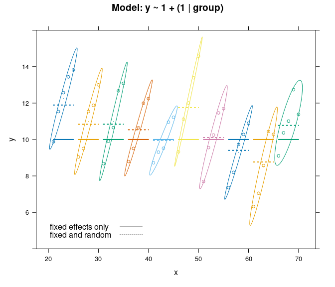

Fitted values from random intercept model.

```r
(plot +
  xyplot(fit ~ x, subset(Data_long, modelcode == "mod0" & effect == "fe"),
         groups=group, type="l", lwd=2) +
  xyplot(fit ~ x, subset(Data_long, modelcode == "mod0" &  effect == "re"),
         groups=group, type="l", lwd=2, lty=3)
) |> update(
  main="Model: y ~ 1 + (1 | group)",
  key=list(
    corner=c(0.05, 0.05),
    text=list(c("fixed effects only","fixed and random")),
    lines=list(lty=c(1, 3))))
```

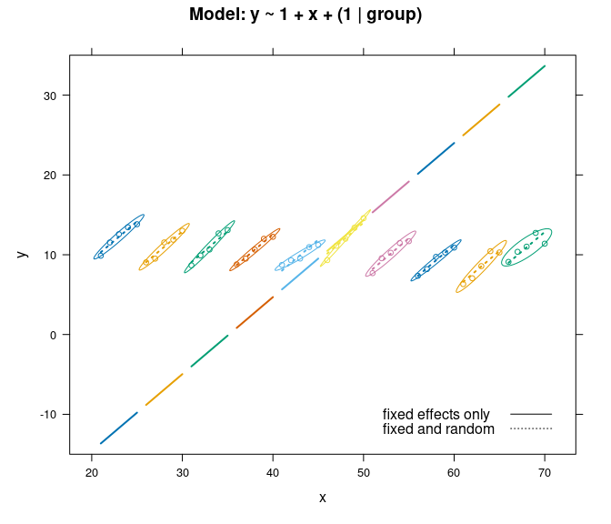

Fitted values from model with random intercept and x as a predictor.

```r
(plot +
  xyplot(fit ~ x, subset(Data_long, modelcode == "mod1" & effect == "fe"),
         groups=group, type="l", lwd=2) +
  xyplot(fit ~ x, subset(Data_long, modelcode == "mod1" & effect == "re"),
         groups=group, type="l", lwd=2, lty=3)
) |> update(
  main="Model: y ~ 1 + x + (1 | group)",
  ylim=c(-15, 35),
  key=list(
    corner=c(0.95, 0.05),
    text=list(c("fixed effects only","fixed and random")),
    lines=list(lty=c(1, 3))))
```

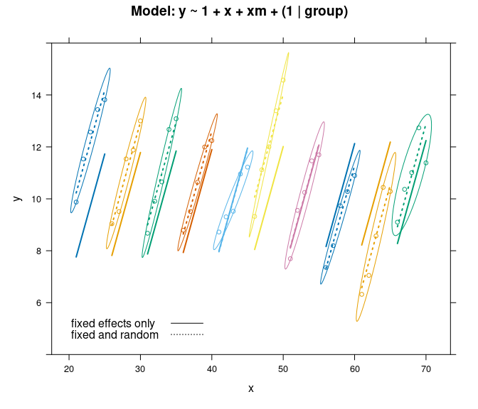

Fitted values from model with random intercept, x, and the group mean of x as predictors.

```r
(plot +
  xyplot(fit ~ x, subset(Data_long, modelcode == "mod2" & effect == "fe"),
         groups=group, type="l", lwd=2) +
  xyplot(fit ~ x, subset(Data_long, modelcode == "mod2" & effect == "re"),
         groups=group, type="l", lwd=2, lty=3)
) |> update(
  main="Model: y ~ 1 + x + xm + (1 | group)",
  ylim=c(4, 16),
  key=list(
    corner=c(0.05, 0.05),
    text=list(c("fixed effects only","fixed and random")),
    lines=list(lty=c(1, 3))))
```

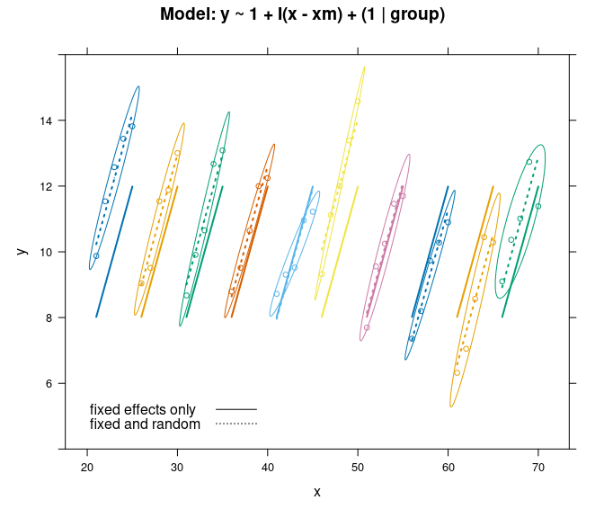

Fitted values from the estimated model generating the data.

```r
(plot +
  xyplot(fit ~ x, subset(Data_long, modelcode == "mod3" & effect == "fe"),
         groups=group, type="l", lwd=2) +
  xyplot(fit ~ x, subset(Data_long, modelcode == "mod3" & effect == "re"),
         groups=group, type="l", lwd=2, lty=3)
) |> update(
  main="Model: y ~ 1 + I(x - xm) + (1 | group)",
  ylim=c(4, 16),
  key=list(
    corner=c(0.05, 0.05),
    text=list(c("fixed effects only","fixed and random")),
    lines=list(lty=c(1, 3))))
```

### Cross-validation of models

We carry out cross-validation resampling individuals within clusters, based on fixed and predicted random effects, and resampling clusters, based on fixed effects only. In order to reduce between-model variability in comparisons of models, the `cv` method applied to the list of models created by the `models` function, performs cross-validation with the same training and validation sets for each model.

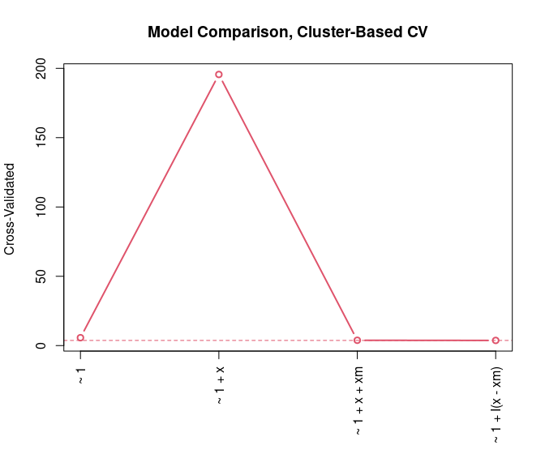

Cross-validation comparing random intercept models with varying fixed effects and with cluster-based resampling.

```r
modlist <- models("~ 1"=fit0, "~ 1 + x"=fit1,
                  "~ 1 + x + xm"=fit2, "~ 1 + I(x - xm)"=fit3)
cvs_clusters <- cv(modlist, data=Data, cluster="group", k=10, seed=6449)
plot(cvs_clusters, main="Model Comparison, Cluster-Based CV")
```

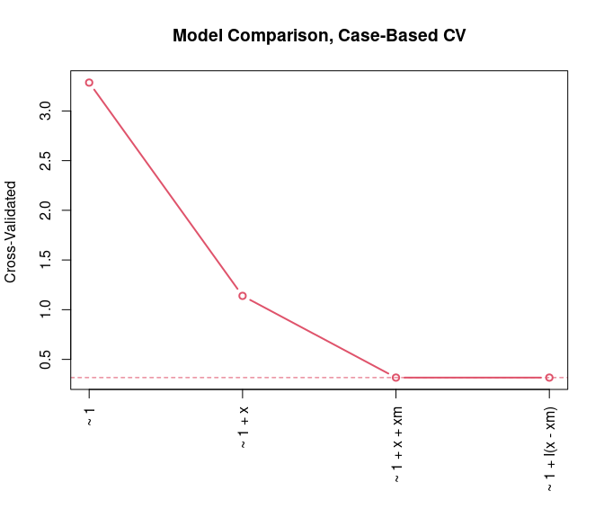

Cross-validation comparing random intercept models with varying fixed effects and with case-based resampling.

```r
cvs_cases <- cv(modlist, data=Data, seed=9693)
plot(cvs_cases, main="Model Comparison, Case-Based CV")
```

In summary, the model with $X$ alone, without the compositional mean of $X$, is assessed as fitting very poorly sampling clusters but, relatively, much better resampling individual cases. The model that includes both $X$ and its compositional mean produces better results using both criteria: resampling individual cases and resampling cluster, illustrating the need to assess models at different levels of resampling.